# Deliverable 2

### Linear Regression

We can use a histogram to check the independent and dependent variables for normality.

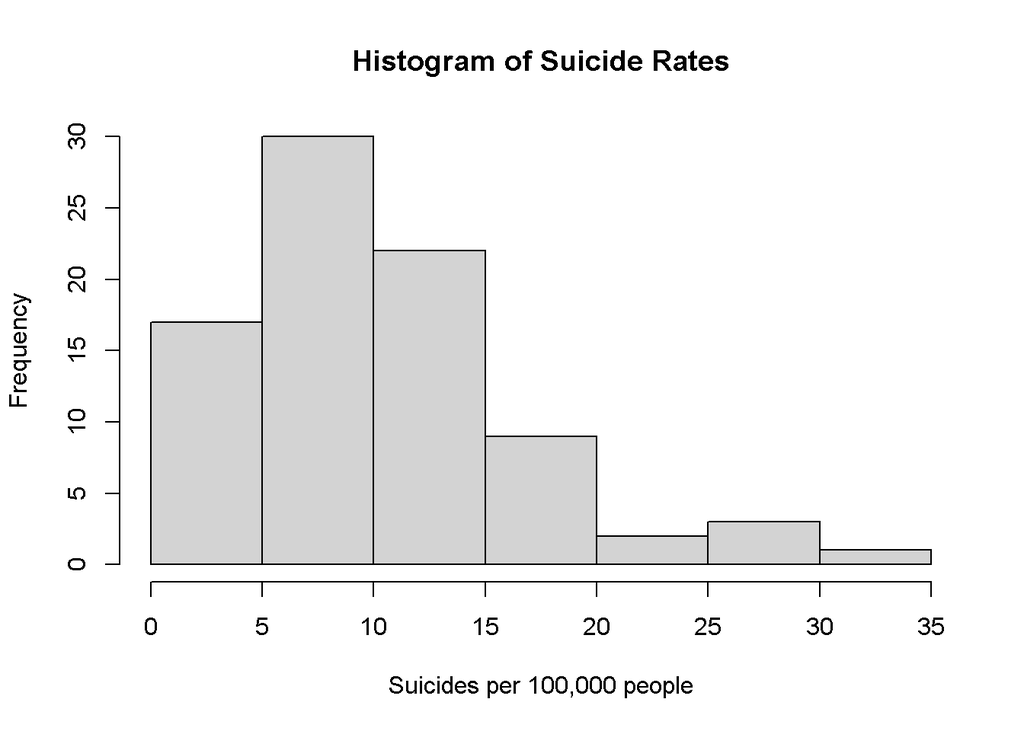

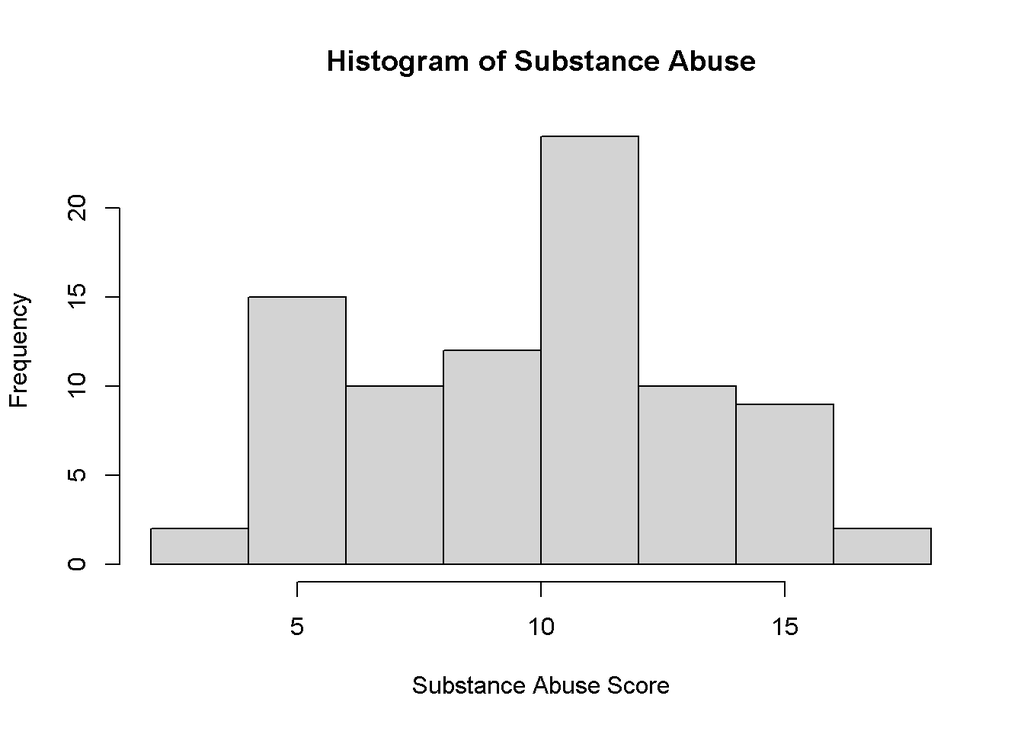

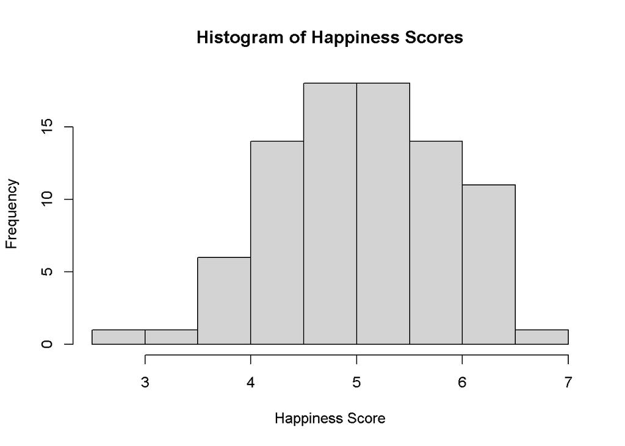

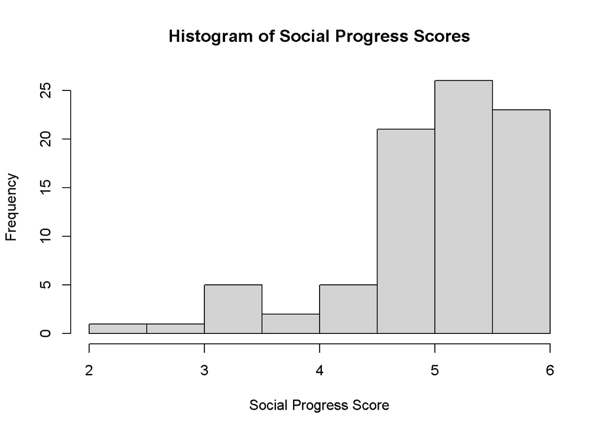

As well as a Shipiro-Wilk tests.

```
##
##  Shapiro-Wilk normality test
##
## data:  MasterTable$SuicideAverage
## W = 0.91627, p-value = 4.242e-05
```

```
##
##  Shapiro-Wilk normality test
##
## data:  MasterTable$SubstanceAbuse
## W = 0.97169, p-value = 0.06083
```

```
##
##  Shapiro-Wilk normality test
##
## data:  MasterTable$Happiness
## W = 0.9809, p-value = 0.2471
```

```
##
##  Shapiro-Wilk normality test
##
## data:  MasterTable$Progress
## W = 0.82832, p-value = 1.817e-08
```

Normality is good enough, Happiness and Substance Abuse also graphically looks normally distributed.

Suicide rates and social progress however show right and left skews and are not normally distributed.

## Here are visuals of the independent variables against the dependent variable.

Scatterplot of Suicide and Substance Abuse

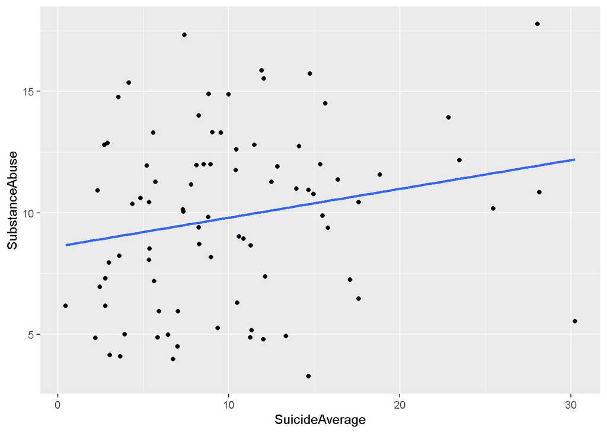

Scatterplot of Suicide and Happiness

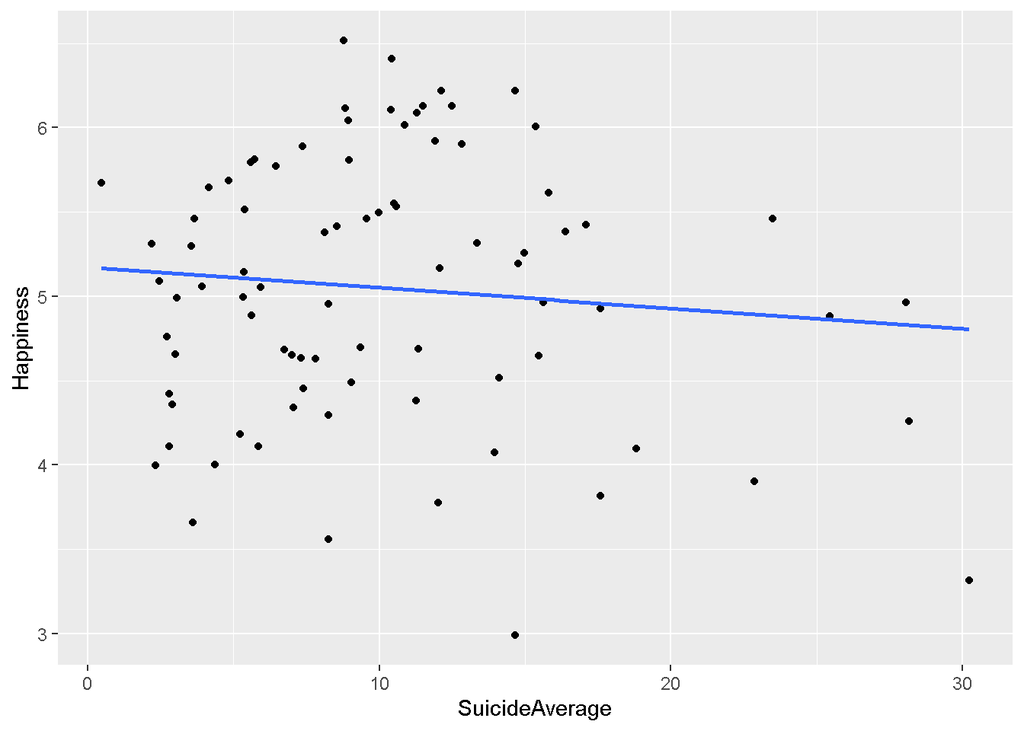

Scatterplot of Suicide and Progress

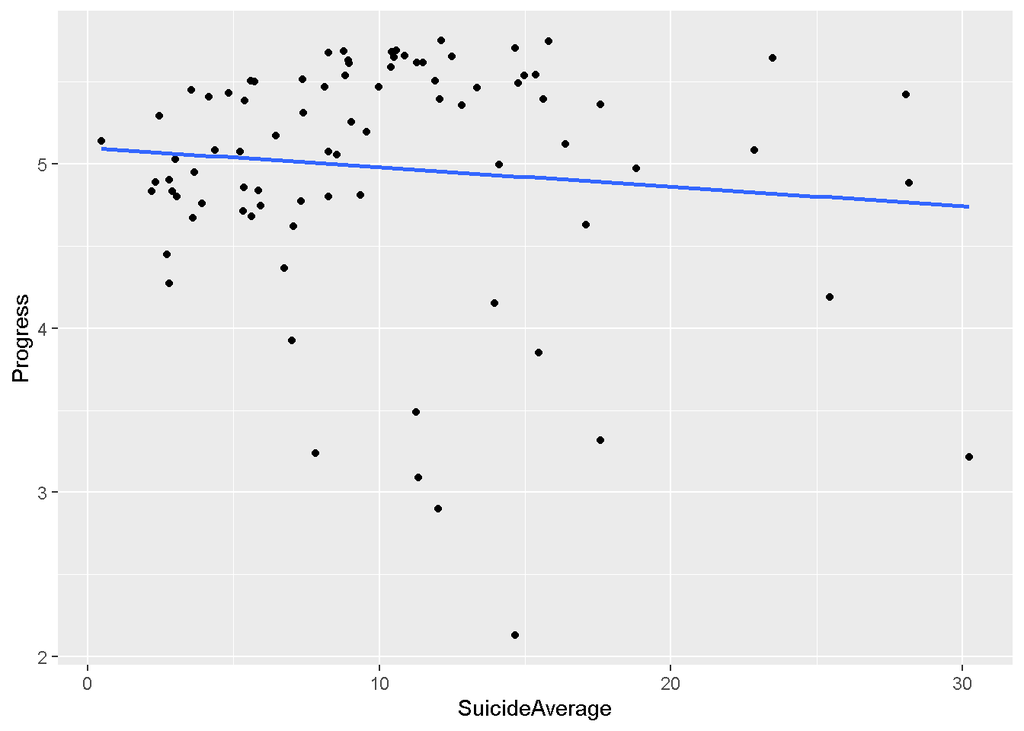